# Exploratory Visualization on Ford GoBike Data

## Visualizing Data

### Who are our customers?

### When people use our service?

### How people use our bikes?

### About "Bike Share for All"

### Where are the Top-100 most popular stations?

## Who use us?

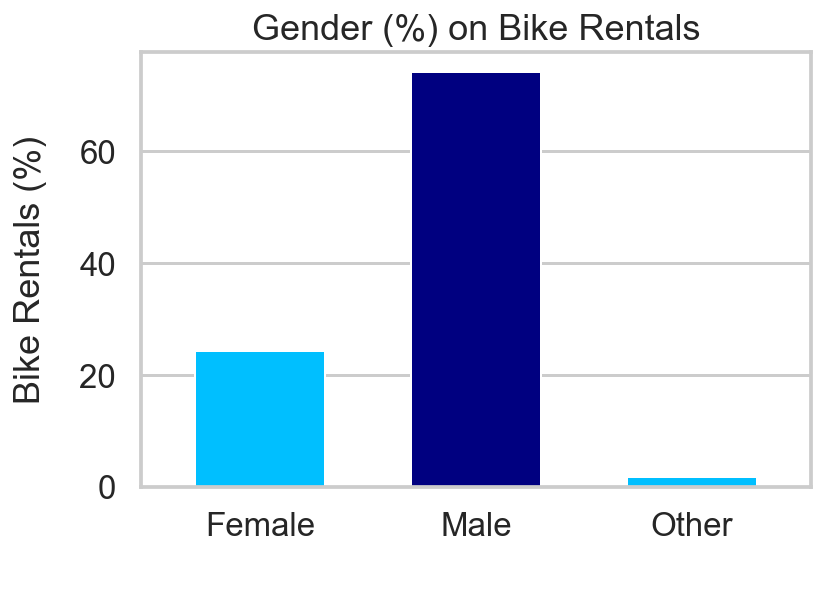

```python
# ### Before cleaning missing value in member_gender
# plt.figure(figsize = [14, 5])
# plt.subplot(121)

# df_trip_by_gender = df.groupby('member_gender').agg({'bike_id':'count'})
# df_trip_by_gender['gender_perc'] = (
#   df_trip_by_gender['bike_id'] / df_trip_by_gender['bike_id'].sum()) * 100

cplt_trip_by_gender = ['deepskyblue', 'navy', 'deepskyblue', 'gray']
# df_trip_by_gender['gender_perc'].plot(kind='bar', alpha = .9, color=cplt_trip_by_gender)

# plt.title('Gender (%) on Bike Rentals - Before Cleansing', fontsize=16, y=1.015)
# plt.xlabel(' ')
## plt.ylabel('Bike Rentals (%)', labelpad=16)
# ax = plt.gca()
# ax.xaxis.grid()
# plt.xticks(rotation=0);


### After cleaning missing value in member_gender
## plt.subplot(122)

df_trip_by_gender_cleaned = df_clean.groupby('member_gender').agg({'bike_id':'count'})
df_trip_by_gender_cleaned['gender_perc'] = (
  df_trip_by_gender_cleaned['bike_id'] / df_trip_by_gender_cleaned['bike_id'].sum()) * 100

df_trip_by_gender_cleaned['gender_perc'].plot(
  kind='bar', color=cplt_trip_by_gender, linewidth = 1, width = .6)

## plt.title('Gender (%) on Bike Rentals - After')
plt.title('Gender (%) on Bike Rentals')
plt.xlabel(' ')
plt.ylabel('Bike Rentals (%)', labelpad=16)
## plt.ylabel(' ')
ax = plt.gca()
ax.xaxis.grid()

plt.xticks(rotation=0);

## print("Before cleaning missing data on gender:\n{}\n".format(df_trip_by_gender['gender_perc'].round(2)))
## print("After cleaning missing data on gender:\n{}\n".format(df_trip_by_gender_cleaned['gender_perc'].round(2)))
```

```
count    3036159.00
mean          35.86
std           10.44
min           18.00
25%           28.00
50%           34.00
75%           41.00
95%           56.00
99%           66.00
max          141.00
Name: member_age, dtype: float64
```

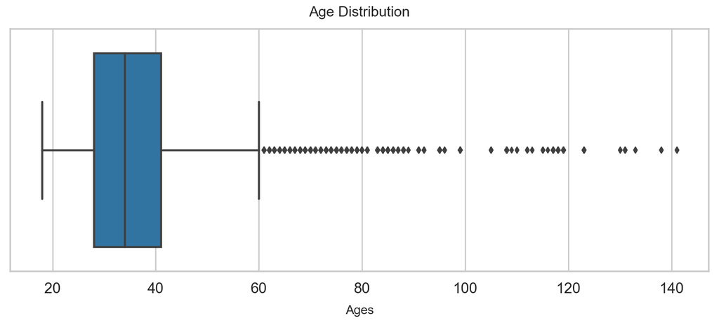

```python
## Age distribution in boxplot
## plt.figure(figsize = [12, 4])
plt.figure(figsize = [14, 5])
base_color = sns.color_palette()[0]
sns.boxplot(data=df_clean, x='member_age', color=base_color, orient='h');
## plt.title("Age Distribution of Ford GoBike customers", fontsize=16, y=1.03)
plt.title("Age Distribution", fontsize=16, y=1.03)
plt.xlabel("Ages", fontsize=14, labelpad=10);

## print(df_clean.member_age.describe().round(2))
df_clean.member_age.describe(percentiles = [.25, .5, .75, .95, .99]).round(2)
```

### Exclude Outliers - Riders older than 66 years old

#### Outliers in member_age

- In Descriptive Statistics, outliers are values less than (Q1 - 1.5 *IQR) or greater than (Q3 + 1.5* IQR).
  - IQR(Interquartile Range): 13.0 = 41.0(Q3) - 28.0(Q1); Outlier Lower Bound: 8.5, Higher Bound: 60.5
  - Outliers in member_age: Lower bound: 8.5 years old & Higher bound: 60.5 years old.
  - Customers older than 60.5 years old can be considered as outliers and excluded.
- The majority (>99%) of customers are younger than 66 years old.
- Records from riders older than 66 years old are excluded in further analyses.

### Age Distribution of Bike Riders in Histogram

- The age distrubition of Ford GoBike riders Users reveals that age 31 is the most common while the average rider age is 35.86 years old.
- Ages between 24 and 40 are the most common rider age group, followed by ages between 41 and 56.

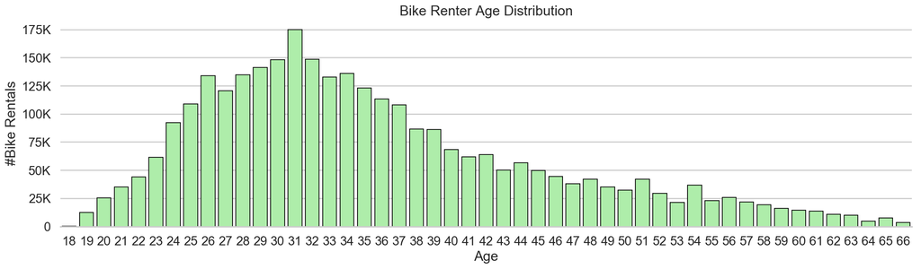

```python
fig, ax = plt.subplots(figsize=(20, 5), dpi = 60)
cpt = sns.color_palette("rainbow")[3]

sns.countplot(x = "member_age", data = df_clean.sort_values("member_age"), color = cpt, lw = 1, edgecolor = "black");

## plt.tight_layout()
cur_axes = plt.gca()
cur_axes.axes.get_yaxis().set_visible(True)
sns.despine(fig, left = True)

plt.xlabel('Age');
plt.ylabel('#Bike Rentals');
plt.gca().yaxis.set_major_formatter(tick.FuncFormatter(transform_axis_fmt))

plt.title("Bike Renter Age Distribution");
```

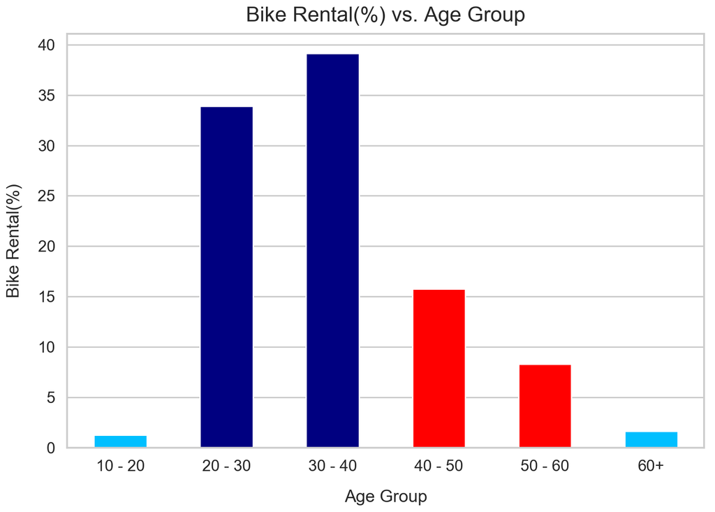

```python
## Define `member_age_bins` based on `member_age`
## Generate a new field for member age group from member_age_bin
df_clean['member_age_bins'] = df_clean['member_age'].apply(lambda x: '10 - 20' if 10 < x <=20
                                                  else '20 - 30' if 20 < x <= 30
                                                  else '30 - 40' if 30 < x <= 40
                                                  else '40 - 50' if 40 < x <= 50
                                                  else '50 - 60' if 50 < x <= 60
                                                  else '60+' if 60 < x
                                                  else x)

df_trip_by_age = df_clean.groupby('member_age_bins').agg({'bike_id':'count'})
df_trip_by_age['perc'] = (df_trip_by_age['bike_id'] / df_trip_by_age['bike_id'].sum())*100

plt_trip_by_age = ['deepskyblue', 'navy', 'navy', 'red', 'red']
df_trip_by_age['perc'].plot(kind='bar', color=plt_trip_by_age, figsize=(12,8))
plt.title('Bike Rental(%) vs. Age Group', fontsize=22, y=1.015)
plt.xlabel('Age Group', labelpad=16)
plt.ylabel('Bike Rental(%)', labelpad=16)

ax = plt.gca()
ax.xaxis.grid()

plt.xticks(rotation=0);
```

### Bike Riders - Subscribers vs. Other Customers

- Riders are in two types, Subscribers vs. Customers with no subscription (Other Customers).
- Subscribers are those customers with subscription. The rest of users are Customers with no subscription.
- The demand on bike rentals on Subscribers varied with season. Non-subscribers, i.e. other customers (green line) did not show much change on demand.

```
Total number of rentals: 3008905
Subscribers: 2664487 (88.55%);	Customers: 344418 (11.45%)
```

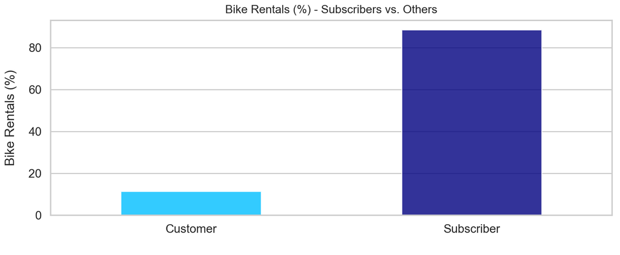

```python
num_rentals, num_featers = df_clean.shape

## aggregate df by user_type
df_rides_usertypes = df_clean.groupby('user_type').size().reset_index(name = 'count')

df_rides_usertypes['user_type_perc'] =  df_rides_usertypes['count'] / num_rentals * 100

print("Total number of rentals: {}".format(num_rentals))
print("Subscribers: {} ({}%);\tCustomers: {} ({}%)".format(
                                        df_rides_usertypes['count'][1],
                                        df_rides_usertypes['user_type_perc'][1].round(2),
                                        df_rides_usertypes['count'][0],
                                        df_rides_usertypes['user_type_perc'][0].round(2)))

plt.figure(figsize = [14, 5])
## plt.figure(figsize=(6, 4))

cplt_rides_usertypes = ['deepskyblue', 'navy', 'deepskyblue', 'gray']
df_rides_usertypes.set_index('user_type', inplace=True)
df_rides_usertypes['user_type_perc'].plot(kind = 'bar', alpha = .8, color = cplt_rides_usertypes)

plt.title('Bike Rentals (%) - Subscribers vs. Others', fontsize=16, y=1.015)
plt.xlabel(' ')
plt.ylabel('Bike Rentals (%)', labelpad=16)

ax = plt.gca()
ax.get_yaxis().set_visible(True)
ax.xaxis.grid()

plt.xticks(rotation=0);
```

## When people use our service?

### Demands since the Go-Live

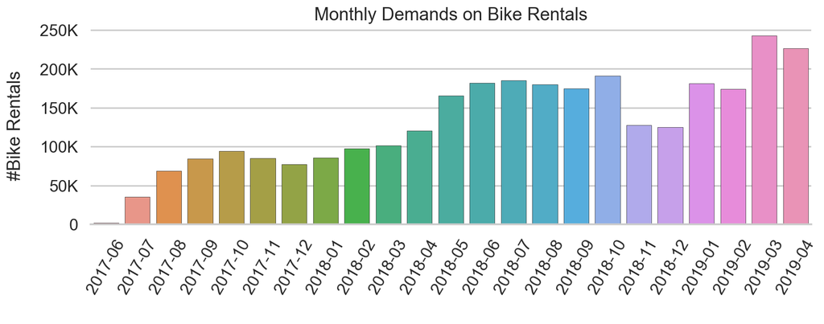

```python
## Bike rentals in each month - Re-write from below:
fig, ax = plt.subplots(figsize = (12,4), dpi = 70)

sns.countplot(x = 'start_time_year_month', lw = 0.3, edgecolor = "black",
              data = df_clean.sort_values(by = ['start_time_year_month']))

plt.title("Monthly Demands on Bike Rentals")
plt.xlabel(" ")
plt.ylabel('#Bike Rentals', labelpad=16)

plt.tight_layout()
ax = plt.gca()
ax.yaxis.set_major_formatter(tick.FuncFormatter(transform_axis_fmt))
sns.despine(fig, left = True)
plt.xticks(rotation=60);
```

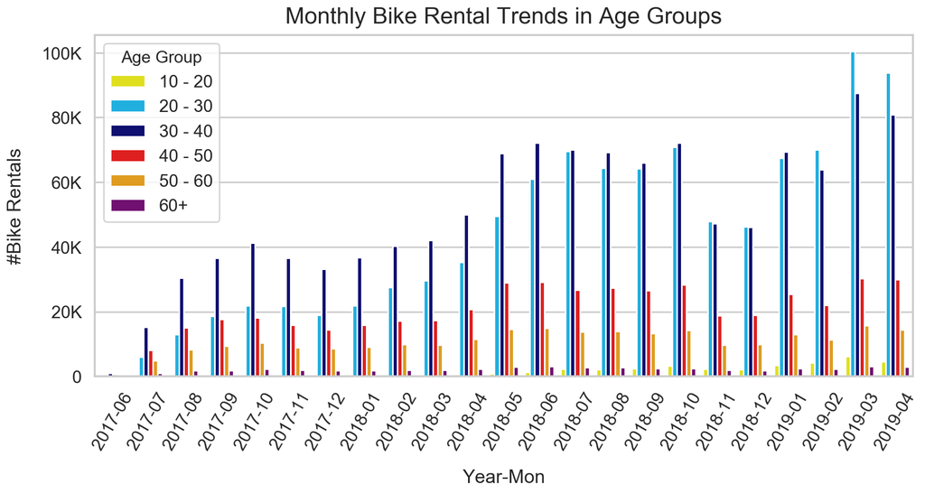

```python
my_palette = {'10 - 20': 'yellow', '20 - 30': 'deepskyblue', '30 - 40': 'navy',
              '40 - 50': 'red', '50 - 60':'orange', "60+": "purple"}

age_bins = ['10 - 20', '20 - 30', '30 - 40', '40 - 50','50 - 60', '60+']

## plt.figure(figsize=(14,8))
plt.figure(figsize = [14, 6])
ax = sns.countplot(x = 'start_time_year_month',
                   hue = 'member_age_bins',
                   palette = my_palette,
                   data=df_clean[df_clean['member_age_bins'].isin(age_bins)].sort_values(
                           by = ['start_time_year_month', 'member_age_bins']))

plt.title('Monthly Bike Rental Trends in Age Groups', fontsize=22, y=1.015)
plt.xlabel('Year-Mon', labelpad=16)
plt.ylabel('#Bike Rentals', labelpad=16)
leg = ax.legend()
leg.set_title('Age Group', prop={'size':16})
ax = plt.gca()
ax.yaxis.set_major_formatter(tick.FuncFormatter(transform_axis_fmt))
plt.xticks(rotation=60);
```

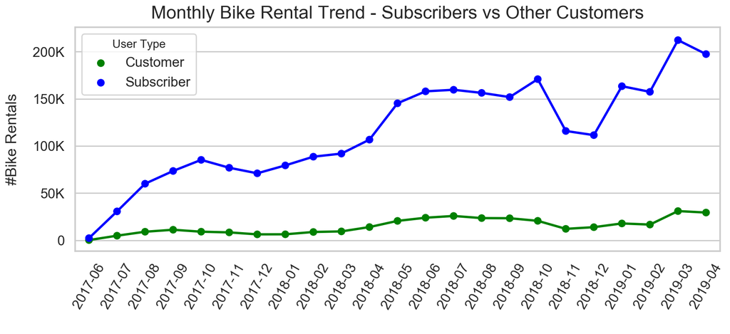

```python
## aggregate the data by year-month and user type:
## df_rides_usertypes_by_month = df_clean.groupby(["start_time_year_month_renamed", "user_type"]).size().reset_index()
df_rides_usertypes_by_month = df_clean.groupby(["start_time_year_month", "user_type"]).size().reset_index()

plt.figure(figsize = [14, 5])
## plt.figure(figsize=(15,9))
my_palette = {'Subscriber':'blue', 'Customer':'green'}
## ax = sns.pointplot(x='start_time_year_month_renamed', y=0, hue='user_type', palette=my_palette, scale=.7,
ax = sns.pointplot(x='start_time_year_month', y=0, hue='user_type', palette=my_palette, scale=.7,
                   data=df_rides_usertypes_by_month)
plt.title('Monthly Bike Rental Trend - Subscribers vs Other Customers', fontsize=22, y=1.015)
plt.xlabel(' ')
plt.ylabel('#Bike Rentals', labelpad=16)
leg = ax.legend()
leg.set_title('User Type',prop={'size':14})
ax = plt.gca()
ax.yaxis.set_major_formatter(tick.FuncFormatter(transform_axis_fmt))
plt.xticks(rotation=60);
```